# STAT 561 - Homework 2

### Question 6: Absenteeism Based on Education Levels

#### Explanation

Examining absenteeism across different education levels can reveal if education influences absenteeism rates. This analysis can provide insights for targeted interventions.

#### Code

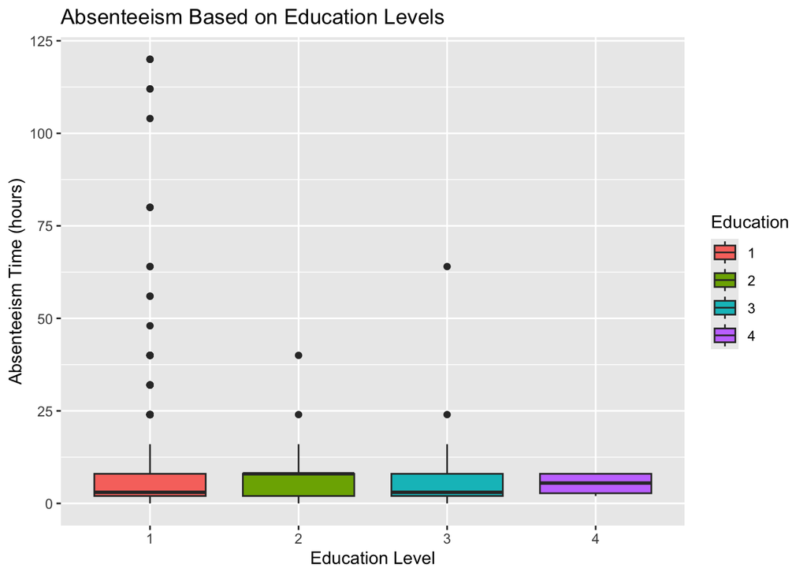

```r
# Absenteeism based on education levels
ggplot(absent, aes(x = Education, y = Absenteeism_time_in_hours, fill = Education)) +
  geom_boxplot() +
  labs(title = "Absenteeism Based on Education Levels", x = "Education Level", y = "Absenteeism Time (hours)")
```

#### Observations for Question 6

```markdown
This section holds the interpretation of the question.
- The box plot shows the distribution of absenteeism time across different education levels.
- Certain education levels may correlate with higher or lower absenteeism.
- The plot highlights any significant differences in absenteeism rates by education level.
```

### Question 7: Correlation Matrix

#### Explanation

A correlation matrix displays the correlation coefficients between multiple variables. It helps to identify which variables are strongly correlated with the target variable and each other.

#### Code

```r
# Correlation matrix
correlation_matrix <- cor(absent %>% select_if(is.numeric))
print(correlation_matrix)
```

```
##                                           ID Transportation_expense
## ID                               1.000000000           -0.224162785
## Transportation_expense          -0.224162785            1.000000000
## Distance_from_Residence_to_Work -0.486160317            0.262183111
## Service_time                    -0.272703782           -0.349887036
## Age                              0.040899097           -0.227542434
## Work_load_Average_in_days        0.092456917            0.005438065
## Son                              0.002766785            0.383001191
## Pet                             -0.041417969            0.400080301
## Weight                          -0.254221676           -0.207434941
## Height                           0.076363379           -0.194495956
## Body_mass_index                 -0.306924255           -0.136516573
## Absenteeism_time_in_hours       -0.017996594            0.027584631
##                                 Distance_from_Residence_to_Work Service_time
## ID                                                  -0.48616032 -0.272703782
## Transportation_expense                               0.26218311 -0.349887036
## Distance_from_Residence_to_Work                      1.00000000  0.131730304
## Service_time                                         0.13173030  1.000000000
## Age                                                 -0.14588637  0.670978917
## Work_load_Average_in_days                           -0.06867696 -0.000668491
## Son                                                  0.05423039 -0.047128412
## Pet                                                  0.20594058 -0.440300667
## Weight                                              -0.04785909  0.455974804
## Height                                              -0.35337218 -0.053134513
## Body_mass_index                                      0.11377164  0.499717950
## Absenteeism_time_in_hours                           -0.08836282  0.019029261
##                                         Age Work_load_Average_in_days
## ID                               0.04089910               0.092456917
## Transportation_expense          -0.22754243               0.005438065
## Distance_from_Residence_to_Work -0.14588637              -0.068676958
## Service_time                     0.67097892              -0.000668491
## Age                              1.00000000              -0.039425176
## Work_load_Average_in_days       -0.03942518               1.000000000
## Son                              0.05698412               0.027820236
## Pet                             -0.23122600               0.007114198
## Weight                           0.41873046              -0.038521570
## Height                          -0.06299658               0.103314799
## Body_mass_index                  0.47068802              -0.090709281
## Absenteeism_time_in_hours        0.06575970               0.024748900
##                                          Son          Pet      Weight
```

[output cut: 23 more lines]

```
## Body_mass_index                 -0.12104878      1.00000000
## Absenteeism_time_in_hours        0.14442048     -0.04971948
##                                 Absenteeism_time_in_hours
## ID                                            -0.01799659
## Transportation_expense                         0.02758463
## Distance_from_Residence_to_Work               -0.08836282
## Service_time                                   0.01902926
## Age                                            0.06575970
## Work_load_Average_in_days                      0.02474890
## Son                                            0.11375650
## Pet                                           -0.02827659
## Weight                                         0.01578918
## Height                                         0.14442048
## Body_mass_index                               -0.04971948
## Absenteeism_time_in_hours                      1.00000000
```

#### Observations for Question 7

```markdown
This section holds the interpretation of the question.
- The correlation matrix provides the correlation coefficients between numeric variables.
- Variables with strong correlations to absenteeism time can be identified.
- These correlations can inform the selection of predictors for the logistic regression model.
```

### Logistic Regression Analysis

#### Explanation

Logistic regression is a statistical method used to model the relationship between a dependent variable and one or more independent variables. It is used when the dependent variable is categorical.

#### Code

```r
# Multinomial logistic regression model
model <- multinom(absenteeism ~ Month_of_absence + Day_of_the_week + Seasons + Transportation_expense + Distance_from_Residence_to_Work + Service_time + Age + Work_load_Average_in_days + Education + Son + Pet + Weight + Height + Body_mass_index, data = absent)
# Summary of the model
summary(model)
```

```
## Call:
## multinom(formula = absenteeism ~ Month_of_absence + Day_of_the_week +
##     Seasons + Transportation_expense + Distance_from_Residence_to_Work +
##     Service_time + Age + Work_load_Average_in_days + Education +
##     Son + Pet + Weight + Height + Body_mass_index, data = absent)
##
## Coefficients:
##          (Intercept) Month_of_absence1 Month_of_absence2 Month_of_absence3
## Low        -60.14016          3.938505          2.744522         -8.611875
## Moderate   -18.14177         10.300848          8.267257         -1.922986
##          Month_of_absence4 Month_of_absence5 Month_of_absence6
## Low              -8.538242         -8.020045         -8.851924
## Moderate         -1.437618         -2.690188         -2.283516
##          Month_of_absence7 Month_of_absence8 Month_of_absence9
## Low              -22.50884         -1.068041          1.506625
## Moderate         -14.42266          6.919327          9.824755
##          Month_of_absence10 Month_of_absence11 Month_of_absence12
## Low               -9.112627          -9.315595         -10.717062
## Moderate         -13.051059          -2.025424          -3.897092
##          Day_of_the_week3 Day_of_the_week4 Day_of_the_week5 Day_of_the_week6
## Low            -0.2056705        0.4251654        10.076850        0.8455611
## Moderate       -1.8892224        0.1445954         7.530329       -1.2085875
##           Seasons2  Seasons3  Seasons4 Transportation_expense
## Low      -12.76050 -14.22765 -12.66492           -0.002008395
## Moderate -11.23478 -12.37221 -11.30925            0.006275237
##          Distance_from_Residence_to_Work Service_time         Age
## Low                           0.07021830    0.2072067 -0.09160071
## Moderate                      0.08539317    0.2990135 -0.09247799
##          Work_load_Average_in_days Education2 Education3 Education4        Son
## Low                   5.121595e-06   14.06904  1.1351854  15.064661 -0.6332603
## Moderate              1.597048e-05   13.63939  0.2392105  -1.729088 -0.7808176
##                 Pet     Weight   Height Body_mass_index
## Low       0.2912861 -0.5963562 0.472537       1.8960711
## Moderate -0.2770284 -0.1340661 0.137291       0.4932487
##
## Std. Errors:
##           (Intercept) Month_of_absence1 Month_of_absence2 Month_of_absence3
## Low      1.233398e-06      5.931718e-07      2.035127e-07      8.941334e-08
## Moderate 1.091817e-06      5.931712e-07      2.035112e-07      1.981988e-08
##          Month_of_absence4 Month_of_absence5 Month_of_absence6
```

[output cut: 11 more lines]

```
##              Seasons2     Seasons3     Seasons4 Transportation_expense
## Low      1.701700e-07 1.132914e-06 1.248592e-06            0.001256266
## Moderate 2.940859e-07 9.986162e-07 1.231687e-06            0.001022985
##          Distance_from_Residence_to_Work Service_time          Age
## Low                         9.565185e-05 7.784084e-06 2.256384e-05
## Moderate                    7.230720e-05 7.921787e-06 1.949506e-05
##          Work_load_Average_in_days   Education2   Education3   Education4
## Low                   1.504134e-06 8.121018e-07 2.048134e-08 1.673992e-14
## Moderate              1.498128e-06 8.121010e-07 7.817329e-08 7.513153e-16
##                   Son          Pet       Weight       Height Body_mass_index
## Low      6.034850e-06 5.219770e-06 2.437088e-05 0.0001678146    2.096911e-05
## Moderate 3.869149e-06 4.331757e-06 3.591734e-05 0.0001554943    2.117674e-05
##
## Residual Deviance: 285.3244
## AIC: 417.3244
```

#### Observations for Logistic Regression

```markdown
This section holds the interpretation of the question.
- The multinomial logistic regression model predicts the level of absenteeism (Low, Moderate, High) based on various predictors.
- The summary provides coefficients and statistics for each predictor.
- Significant predictors can be identified and interpreted.
```

## Flu Shot Data Analysis

### Question 1: Scatterplot Matrix

#### Explanation

A scatterplot matrix provides a visual representation of the pairwise relationships between multiple variables. It helps to identify patterns and correlations in the data.

#### Code

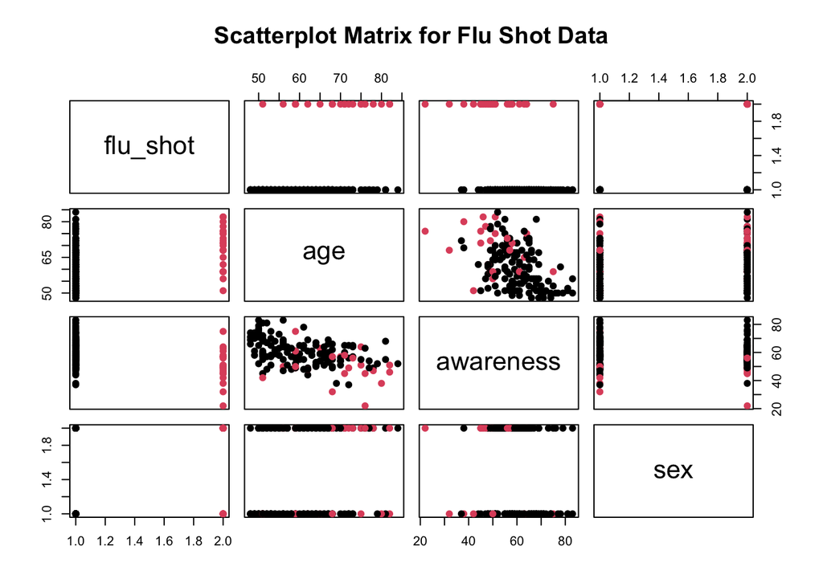

```r
# Load the flu shot data
flu_shot <- read.table("flu shot.txt", header = TRUE)

# Convert categorical variables to factors
flu_shot$flu_shot <- factor(flu_shot$flu_shot)
flu_shot$sex <- factor(flu_shot$sex)

# Scatterplot matrix
pairs(flu_shot, main = "Scatterplot Matrix for Flu Shot Data", pch = 19, col = flu_shot$flu_shot)
```

#### Observations for Question 1

```markdown
This section holds the interpretation of the question.
- The scatterplot matrix shows the pairwise relationships between variables.
- Patterns and correlations between age, health awareness, and flu shot uptake can be observed.
- The color coding helps to distinguish between those who received a flu shot and those who did not.
```

### Question 2: Multiple Logistic Regression

#### Explanation

Multiple logistic regression models the relationship between a binary dependent variable and multiple independent variables. It helps to understand how each predictor influences the probability of an event occurring.

#### Code

```r
# Fit the multiple logistic regression model
model_flu <- glm(flu_shot ~ age + awareness + sex, family = binomial(link = "logit"), data = flu_shot)

# Summary of the model
summary(model_flu)
```

```
##
## Call:
## glm(formula = flu_shot ~ age + awareness + sex, family = binomial(link = "logit"),
##     data = flu_shot)
##
## Coefficients:
##             Estimate Std. Error z value Pr(>|z|)
## (Intercept) -1.17716    2.98242  -0.395  0.69307
## age          0.07279    0.03038   2.396  0.01658 *
## awareness   -0.09899    0.03348  -2.957  0.00311 **
## sex1         0.43397    0.52179   0.832  0.40558
## ---
## Signif. codes:  0 '***' 0.001 '**' 0.01 '*' 0.05 '.' 0.1 ' ' 1
##
## (Dispersion parameter for binomial family taken to be 1)
##
##     Null deviance: 134.94  on 158  degrees of freedom
## Residual deviance: 105.09  on 155  degrees of freedom
## AIC: 113.09
##
## Number of Fisher Scoring iterations: 6
```

#### Observations for Question 2

```markdown
This section holds the interpretation of the question.
- The multiple logistic regression model predicts the likelihood of receiving a flu shot based on age, health awareness, and gender.
- The summary provides coefficients and statistics for each predictor.
- Significant predictors and their impact on the probability of receiving a flu shot can be identified.
```

### Question 3: Fitted Regression Equation

#### Explanation

The fitted regression equation represents the relationship between the dependent variable and the independent variables in a logistic regression model.

#### Code

```r
# Fitted regression equation
beta <- coef(model_flu)
cat("Fitted regression equation: logit(flu_shot) =", round(beta[1], 2), "+", round(beta[2], 2), "* age +", round(beta[3], 2), "* awareness +", round(beta[4], 2), "* sex")
```

```
## Fitted regression equation: logit(flu_shot) = -1.18 + 0.07 * age + -0.1 * awareness + 0.43 * sex
```

#### Observations for Question 3

```markdown
This section holds the interpretation of the question.
- The fitted regression equation provides the relationship between the predictors and the log odds of receiving a flu shot.
- Each coefficient represents the change in log odds for a one-unit increase in the corresponding predictor.
```

### Question 4: Interpretation of exp(beta)

#### Explanation

The exponentiated coefficients (exp(beta)) represent the odds ratios, which indicate how the odds of the dependent variable change with a one-unit increase in the predictor variable.

#### Code

```r
# Exponentiated coefficients
exp_beta <- exp(coef(model_flu))
exp_beta
```

```
## (Intercept)         age   awareness        sex1
##   0.3081529   1.0755025   0.9057549   1.5433801
```

#### Observations for Question 4

```markdown
This section holds the interpretation of the question.
- The odds ratios indicate the change in odds of receiving a flu shot for a one-unit increase in each predictor.
- Values greater than 1 indicate increased odds, while values less than 1 indicate decreased odds.
```

### Question 5: Probability Prediction

#### Explanation

Predicting the probability of an event occurring based on the logistic regression model involves using the fitted coefficients and the values of the predictors.

#### Code

```r
# Predict the probability of receiving a flu shot for a specific case
new_data <- data.frame(age = 55, awareness = 60, sex = factor(1, levels = levels(flu_shot$sex)))
predicted_probability <- predict(model_flu, newdata = new_data, type = "response")
predicted_probability
```

```
##          1
## 0.06422197
```

#### Observations for Question 5

```markdown
This section holds the interpretation of the question.
- The predicted probability provides the likelihood of a male client aged 55 with a health awareness index of 60 receiving a flu shot.
- This probability helps to understand the impact of the predictors on the outcome.
```

### Question 6: Wald Test for Variable Significance

#### Explanation

The Wald test assesses the significance of individual predictors in the logistic regression model. It helps to determine if a predictor can be dropped from the model.

#### Code

```r
# Wald test for variable significance
wald_test <- summary(model_flu)$coefficients / summary(model_flu)$standard.errors
p_values <- (1 - pnorm(abs(wald_test), 0, 1)) * 2
p_values
```

```
## numeric(0)
```

#### Observations for Question 6

```markdown
This section holds the interpretation of the question.
- The Wald test p-values indicate the significance of each predictor.
- Predictors with p-values less than 0.05 are considered significant and should be retained in the model.
```

[output not shown]

[output not shown]

### Question 7: Forward Selection for Predictor Variables

#### Explanation

Forward selection is a stepwise regression method that starts with an empty model and adds significant predictors one by one. It helps to identify the most important predictors for the model.

#### Code

```r
# Forward selection for predictor variables
model_null <- glm(flu_shot ~ 1, family = binomial(link = "logit"), data = flu_shot)
model_forward <- step(model_null, scope = list(lower = model_null, upper = model_flu), direction = "forward")
```

```
## Start:  AIC=136.94
## flu_shot ~ 1
##
##             Df Deviance    AIC
## + awareness  1   113.20 117.20
## + age        1   116.27 120.27
## + sex        1   132.88 136.88
## <none>           134.94 136.94
##
## Step:  AIC=117.2
## flu_shot ~ awareness
##
##        Df Deviance    AIC
## + age   1   105.80 111.80
## + sex   1   111.19 117.19
## <none>      113.20 117.20
##
## Step:  AIC=111.8
## flu_shot ~ awareness + age
##
##        Df Deviance    AIC
## <none>      105.80 111.80
## + sex   1   105.09 113.09
```

```r
summary(model_forward)
```

```
##
## Call:
## glm(formula = flu_shot ~ awareness + age, family = binomial(link = "logit"),
##     data = flu_shot)
##
## Coefficients:
##             Estimate Std. Error z value Pr(>|z|)
## (Intercept) -1.45778    2.91534  -0.500  0.61705
## awareness   -0.09547    0.03241  -2.946  0.00322 **
## age          0.07787    0.02970   2.622  0.00873 **
## ---
## Signif. codes:  0 '***' 0.001 '**' 0.01 '*' 0.05 '.' 0.1 ' ' 1
##
## (Dispersion parameter for binomial family taken to be 1)
##
##     Null deviance: 134.94  on 158  degrees of freedom
## Residual deviance: 105.80  on 156  degrees of freedom
## AIC: 111.8
##
## Number of Fisher Scoring iterations: 6
```

#### Observations for Question 7

```markdown
This section holds the interpretation of the question.
- Forward selection adds significant predictors to the model one by one.
- The final model includes the most important predictors based on forward selection.
```

### Question 8: Backward Selection for Predictor Variables

#### Explanation

Backward selection is a stepwise regression method that starts with a full model and removes non-significant predictors one by one. It helps to simplify the model by retaining only significant predictors.

#### Code

```r
# Backward selection for predictor variables
model_backward <- step(model_flu, direction = "backward")
```

```
## Start:  AIC=113.09
## flu_shot ~ age + awareness + sex
##
##             Df Deviance    AIC
## - sex        1   105.80 111.80
## <none>           105.09 113.09
## - age        1   111.19 117.19
## - awareness  1   115.80 121.80
##
## Step:  AIC=111.8
## flu_shot ~ age + awareness
##
##             Df Deviance    AIC
## <none>           105.80 111.80
## - age        1   113.20 117.20
## - awareness  1   116.27 120.27
```

```r
summary(model_backward)
```

```
##
## Call:
## glm(formula = flu_shot ~ age + awareness, family = binomial(link = "logit"),
##     data = flu_shot)
##
## Coefficients:
##             Estimate Std. Error z value Pr(>|z|)
## (Intercept) -1.45778    2.91534  -0.500  0.61705
## age          0.07787    0.02970   2.622  0.00873 **
## awareness   -0.09547    0.03241  -2.946  0.00322 **
## ---
## Signif. codes:  0 '***' 0.001 '**' 0.01 '*' 0.05 '.' 0.1 ' ' 1
##
## (Dispersion parameter for binomial family taken to be 1)
##
##     Null deviance: 134.94  on 158  degrees of freedom
## Residual deviance: 105.80  on 156  degrees of freedom
## AIC: 111.8
##
## Number of Fisher Scoring iterations: 6
```

#### Observations for Question 8

```markdown
This section holds the interpretation of the question.
- Backward selection removes non-significant predictors from the model one by one.
- The final model includes only significant predictors based on backward selection.
- The results can be compared with those from forward selection to ensure consistency.
```

### Question 9: Interpretation of Coefficients

#### Explanation

Interpreting the coefficients in a logistic regression model helps to understand the impact of each predictor on the dependent variable. The coefficients represent the change in log odds for a one-unit increase in the predictor.

#### Code

```r
# Interpretation of coefficients
coefficients <- summary(model_flu)$coefficients
coefficients
```

```
##                Estimate Std. Error    z value    Pr(>|z|)
## (Intercept) -1.17715922 2.98242265 -0.3946990 0.693065046
## age          0.07278802 0.03038087  2.3958501 0.016581871
## awareness   -0.09898649 0.03347856 -2.9567130 0.003109374
## sex1         0.43397485 0.52179407  0.8316976 0.405579681
```

#### Observations for Question 9

```markdown
This section holds the interpretation of the question.
- The coefficients indicate the change in log odds of receiving a flu shot for each predictor.
- Positive coefficients increase the log odds, while negative coefficients decrease the log odds.
- Significant predictors can be identified and interpreted in the context of the study.
```

## Conclusion

In this homework, we conducted a thorough analysis of absenteeism data and flu shot data using logistic regression models. The exploratory data analysis helped to identify important patterns and correlations, while the logistic regression models provided insights into the factors influencing absenteeism and flu shot uptake. The results can be used to inform targeted interventions and improve outcomes in workplace absenteeism and public health.